# Lecture 6: Regression Analysis

L2 - Statistics

Gustave Kenedi

2026-03-16

## Recap quiz

[figure not shown]

Or click here: [link to Wooclap](https://app.wooclap.com/L2STATHP?from=instruction-slide)

## Today’s lecture

**The big question:** How can we quantify and test the relationship between two numeric variables?

**1. Motivation & data**

2. The Simple Linear Regression model

3. Ordinary Least Squares estimation

4. Goodness of fit ($R^2$)

5. Inference: standard errors & the $t$-test

6. Reading regression output

# Motivation & data

## Why regression?

So far in this course we have learned to:

- **Describe** distributions of a single variable (mean, variance, histograms)
- **Quantify uncertainty** around estimates (confidence intervals)
- **Test hypotheses** about population parameters (t-tests, z-tests)

**But we haven’t yet answered:** *How do two variables relate to each other and how can we use one to predict the other?*

**Regression** is the workhorse tool for answering exactly this question. It lets us: **summarise** a relationship with a line, **estimate** the average change in $y$ for a one-unit change in $x$, and **test** whether that relationship is statistically significant.

## Class size and student performance

**A classic policy question:** Does reducing class size improve student learning?

- Smaller classes cost money (more teachers, more classrooms) but may improve outcomes.
- Class size reduction has been at the heart of education policy debates for decades.

**Our empirical application:** [Angrist & Lavy (1999)](http://piketty.pse.ens.fr/files/AngristLavy1999.pdf)

**The dataset**

Test scores and class/school characteristics for **5th graders** (10/11 years old) in Jewish public elementary schools in **Israel in 1991**.

- $n \approx 2{,}000$ classes
- National standardised tests in **mathematics** and **reading** (Hebrew), scaled 1–100
- Key variables: `classize` (class size), `avgmath` (avg. math score), `avgverb` (avg. verbal score)

## Your turn! #1

1. Load the data below as `grades`. *(Hint: `read_dta()` from the `haven` package reads Stata `.dta` files.)*

```r
library(haven)
grades <- read_dta("https://www.dropbox.com/s/wwp2cs9f0dubmhr/grade5.dta?dl=1")
```

2. Describe the dataset:
   - What is the unit of observation (what does each row represent)?
   - How many observations are there?
   - View the dataset. What variables do we have?
   - Use `skim()` from the `skimr` package on `classize`, `avgmath`, and `avgverb`. *(Hint: `select()` the three variables and pipe to `skim()`.)*
3. Do you have any prior intuitions about the relationship between class size and student achievement? What would you do to get a first visual insight?
4. Compute the correlation between `classize` and both `avgmath` and `avgverb`. Is the relationship positive/negative? Strong/weak?

## Class size and student performance: scatter plots

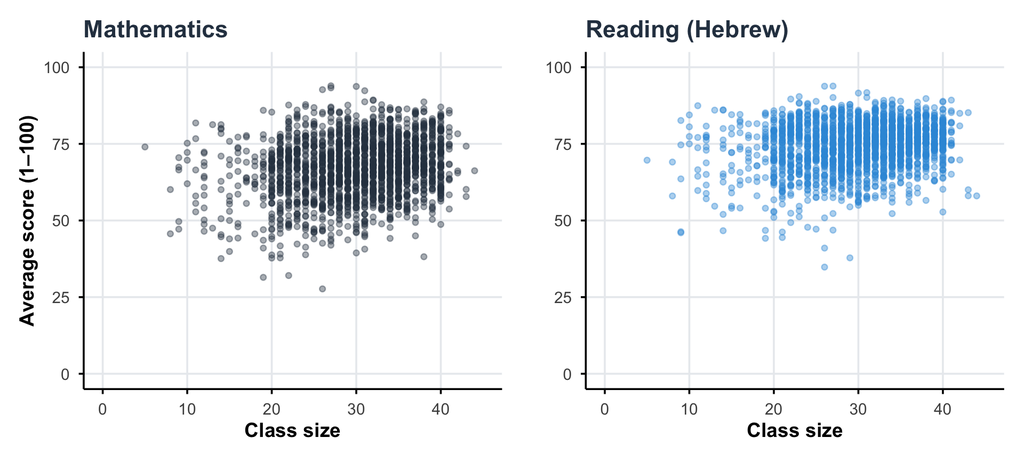

**What do you notice?** Is there a clear pattern?

→ For simplicity, we will **focus on mathematics** for the rest of this lecture.

## Correlation

Recall from Lecture 2: **correlation** measures the *linear* association between two variables, $r \in [-1, 1]$.

```r
cor(grades$classize, grades$avgmath)
```

```
[1] 0.2171555
```

**Note**

The correlation is slightly positive: larger classes are *weakly* associated with *higher* math scores. Surprising?

Correlation gives us a single number, but it doesn’t answer:

- By *how much* does the average math score change with a 1-student increase in class size?
- Is this relationship statistically different from zero?

→ We need **regression**.

## Class size and math score: which line fits best?

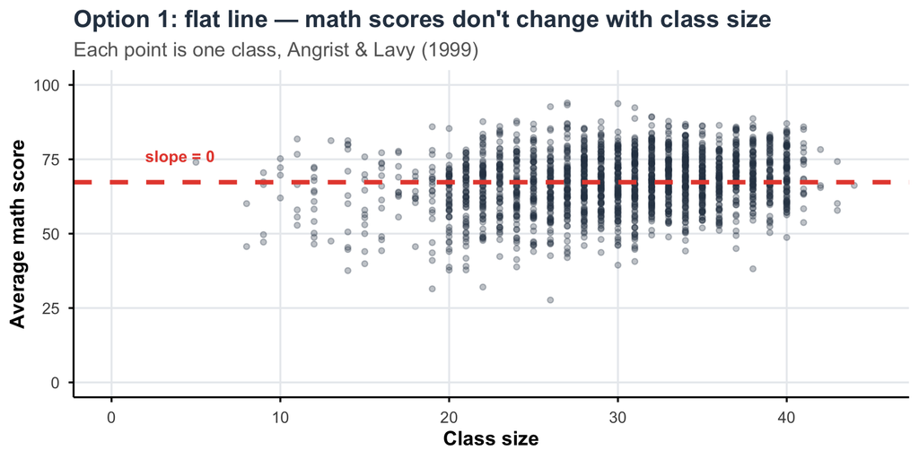

But the correlation is positive so we should have a positive slope

## Class size and math score: which line fits best?

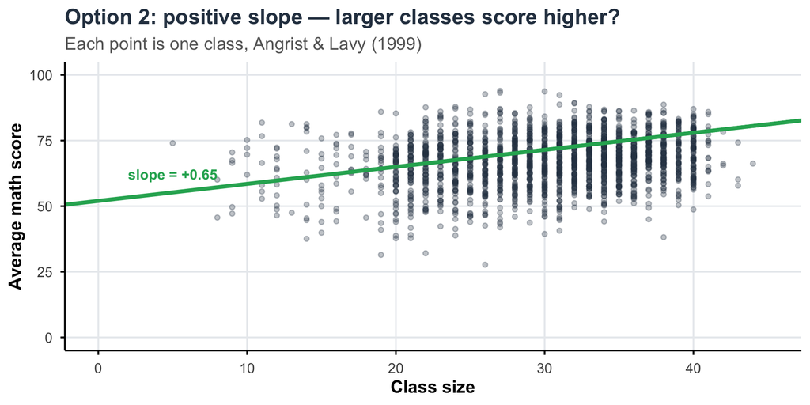

Positive relationship, but perhaps too steep? $\rightarrow$ we need a **principled rule**

## What makes a line “good”?

Intuitively, a good line should be **close to the data points**: the vertical gaps between each actual score and the predicted score should be small.

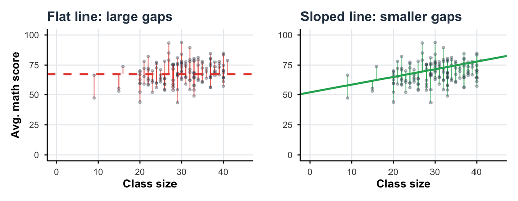

The sloped line *looks* better, but why exactly? And how do we find the *best* possible line? → **Ordinary Least Squares (OLS)** answers this formally.

## Today’s lecture

**The big question:** How can we quantify and test the relationship between two numeric variables?

1. Motivation & data

**2. The Simple Linear Regression model**

3. Ordinary Least Squares estimation

4. Goodness of fit ($R^2$)

5. Inference: standard errors & the $t$-test

6. Reading regression output

# Simple Linear Regression

## From scatter plot to a line

We want to **summarise** the relationship between class size $(x)$ and average math score $(y)$ with a line.

**Two variables**

- **Outcome (dependent) variable**: $y_i \rightarrow$ *average math score* of class $i$
- **Explanatory (independent) variable**: $x_i \rightarrow$ *class size* of class $i$

A line with **intercept** $\hat{\beta}_0$ and **slope** $\hat{\beta}_1$ predicts:

$$\hat{y}_i = \hat{\beta}_0 + \hat{\beta}_1 x_i$$

- $\hat{y}_i$ is our **prediction** of $y_i$ given $x_i$
- **Which** line? There are infinitely many $\rightarrow$ we need a rule to pick the best one.

## Intercept and slope: a refresher

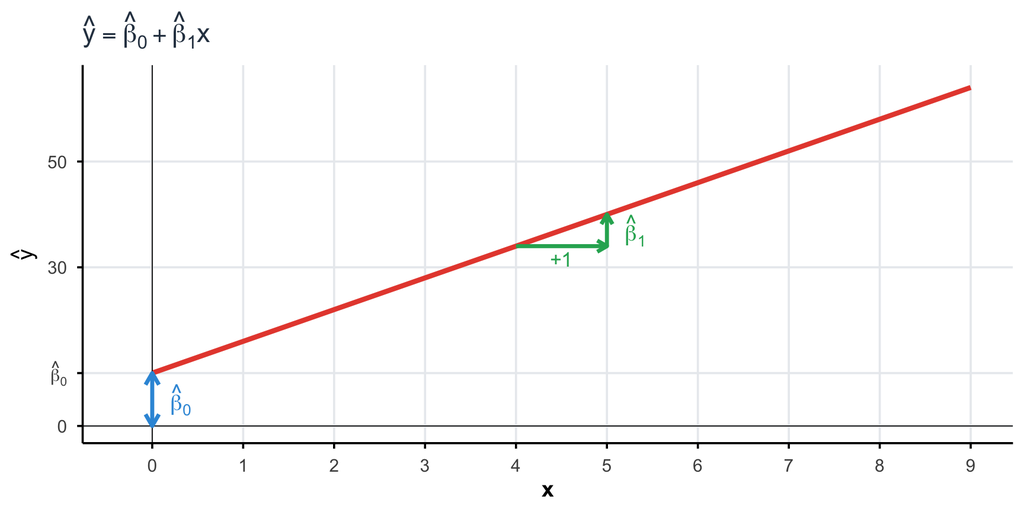

|  | Definition |
| --- | --- |
| **Intercept** $\hat{\beta}_0$ | Predicted value of $y$ when $x = 0$ |
| **Slope** $\hat{\beta}_1$ | Predicted change in $y$ for a **1-unit** increase in $x$ |

## If $x$ perfectly explained $y$…

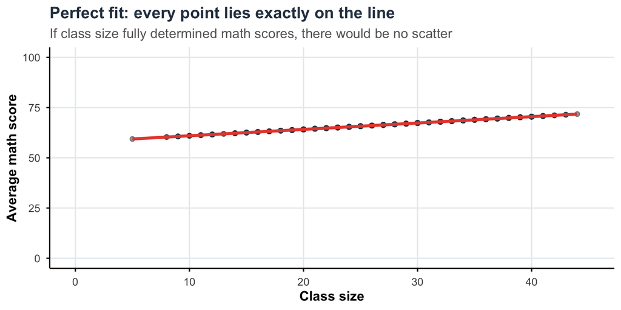

In this world: $y_i = \hat{\beta}_0 + \hat{\beta}_1 x_i \rightarrow$ **no unexplained variation**.

## The residual

In practice, a student’s math score depends on many things beyond class size.

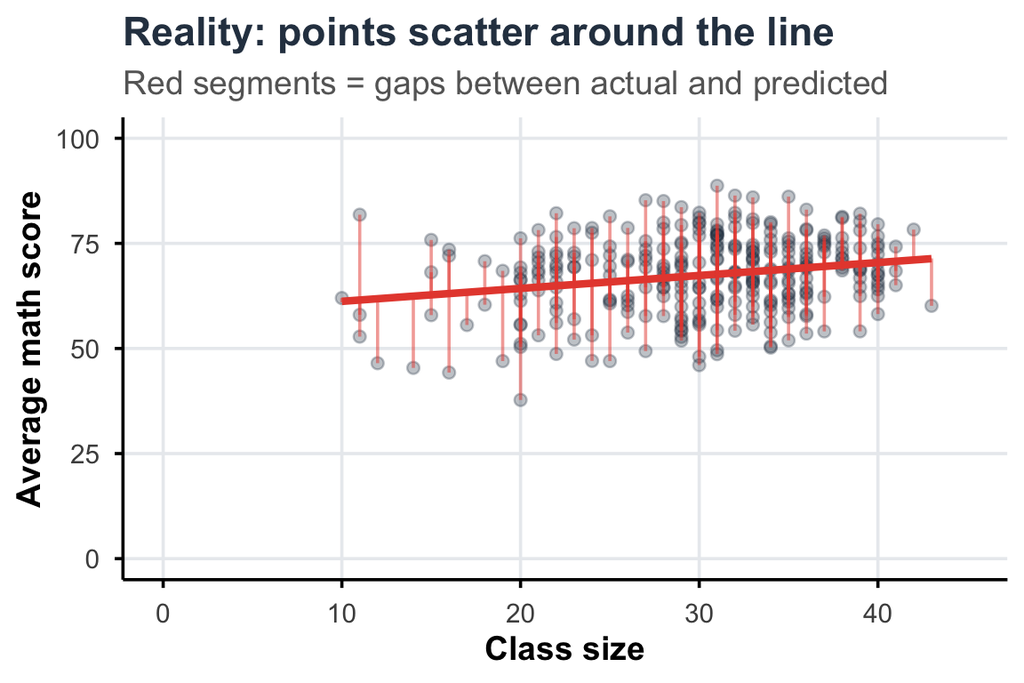

We call each gap a **residual**:

$$e_i = y_i - \hat{y}_i$$

The actual value decomposes as:

$$\boxed{y_i = \underbrace{\hat{\beta}_0 + \hat{\beta}_1 x_i}_{\text{prediction}} + \underbrace{e_i}_{\text{residual}}}$$

**Note**

The residual $e_i$ captures everything that affects $y_i$ **other than** $x_i$ (talent, family background, teaching quality, etc).

## Today’s lecture

**The big question:** How can we quantify and test the relationship between two numeric variables?

1. Motivation & data

2. The Simple Linear Regression model

**3. Ordinary Least Squares estimation**

4. Goodness of fit ($R^2$)

5. Inference: standard errors & the $t$-test

6. Reading regression output

# OLS Estimation

## Which line? The OLS criterion

We need a rule to choose $(\hat{\beta}_0, \hat{\beta}_1)$. A natural goal: make the residuals as **small as possible**.

**Problem with summing residuals directly:** positive and negative errors cancel.

**Solution:** Minimise the **Sum of Squared Residuals (SSR)**:

$$\text{SSR} = \sum_{i=1}^n e_i^2 = \sum_{i=1}^n (y_i - \hat{\beta}_0 - \hat{\beta}_1 x_i)^2$$

**Ordinary Least Squares (OLS) Definition**

**OLS** chooses $(\hat{\beta}_0, \hat{\beta}_1)$ to **minimise** the sum of squared residuals.

## OLS: squared residuals visually

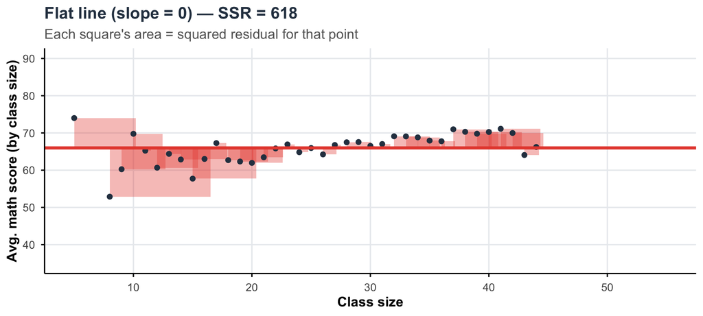

## OLS: squared residuals visually

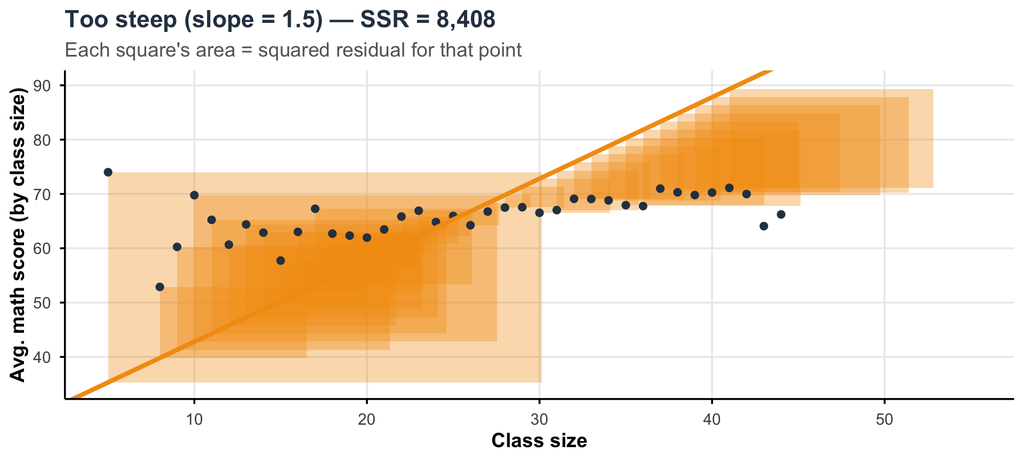

## OLS: squared residuals visually

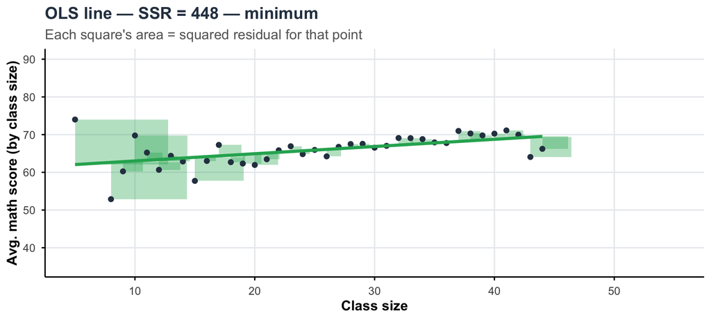

## OLS coefficient formulas

Solving the minimisation problem algebraically yields unique formulas:

**OLS formulas**

$$\hat{\beta}_1 = \frac{Cov(x,y)}{Var(x)} = \frac{\sum_{i=1}^n (x_i - \bar{x})(y_i - \bar{y})}{\sum_{i=1}^n (x_i - \bar{x})^2}$$

$$\hat{\beta}_0 = \bar{y} - \hat{\beta}_1 \cdot \bar{x}$$

**Key observations:**

- $\hat{\beta}_1$ is the ratio of the *covariance* of $x$ and $y$ to the *variance* of $x$
- The line always passes through the point $(\bar{x}, \bar{y})$: the means of both variables
- The formulas have unique solutions

## OLS in R: `lm()`

```r
reg <- lm(avgmath ~ classize, data = grades)
reg
```

```
Call:
lm(formula = avgmath ~ classize, data = grades)

Coefficients:
(Intercept)     classize
    57.7939       0.3175
```

So our estimated line is:

$$\widehat{\text{avg. math score}}_i = 57.79 + 0.32 \times \text{class size}_i$$

## Interpreting OLS coefficients

$$\widehat{\text{avg. math score}}_i = 57.79 + 0.32 \times \text{class size}_i$$

**Interpretation rules**

- **Intercept** $\hat{\beta}_0$: The *predicted* average math score when class size = 0.
  - Here: $\hat{\beta}_0 = 57.79$, not economically meaningful (class size = 0 is impossible), but mathematically necessary.
- **Slope** $\hat{\beta}_1$: The *predicted* change in average math score *associated with* a **1-student increase** in class size.
  - Here: $\hat{\beta}_1 = 0.32$, a 1-student increase in class size is **associated** with a 0.32 point increase in average math score, on average.

**Correlation ≠ Causation**

We use the word **associated**, not *causes*. This positive relationship does not mean larger classes *improve* performance; there may be confounding factors.

## Making predictions

$$\widehat{\text{avg. math score}}_i = 57.79 + 0.32 \times \text{class size}_i$$

**Q:** What is the predicted average math score for a class of **30 students**?

$$\hat{y}_{x=30} = 57.79 + 0.32 \times 30 = 67.32$$

**Q:** For a class of **20 students**?

$$\hat{y}_{x=20} = 57.79 + 0.32 \times 20 = 64.14$$

**Q:** What is the predicted *difference* between a class of 30 and a class of 20?

$$\hat{y}_{x=30} - \hat{y}_{x=20} = \hat{\beta}_1 \times (30-20) = 0.32 \times 10 = 3.17$$

This is just $\hat{\beta}_1$ times the difference in $x$!

## Properties of OLS estimates

OLS residuals and predictions have useful algebraic properties:

1. **Residuals sum to zero:** $\displaystyle\sum_{i=1}^n e_i = 0$
2. **Predictions average to $\bar{y}$:** $\displaystyle\frac{1}{n}\sum_{i=1}^n \hat{y}_i = \bar{y}$
3. **Residuals are uncorrelated with $x$:** $Cov(x_i, e_i) = 0$ (by construction)
4. **Residuals are uncorrelated with $\hat{y}$:** $Cov(\hat{y}_i, e_i) = 0$

**Note**

These properties hold **by construction** for any OLS line: they are not assumptions about the world, just algebraic facts that follow from the minimisation.

## Your turn! #2

1. Regress `avgmath` on `classize` using `lm()`. Store the result as `reg_math`. Interpret both coefficients.
2. Compute $\hat{\beta}_1$ manually using the formula $\hat{\beta}_1 = Cov(x, y) / Var(x)$. *(Hint: use `cov()` and `var()`.)* Then compute $\hat{\beta}_0 = \bar{y} - \hat{\beta}_1 \bar{x}$. Do they match?
3. What is the predicted average math score for a class of 25 students? Of 35 students?
4. Repeat steps 1 and 3 for `avgverb` (verbal scores). Store the result as `reg_verb`. How do the results compare?
5. Add the regression line to your scatter plot from Your Turn #1. *(Hint: use `geom_smooth(method = "lm", se = FALSE)`.)*

## Class size and math score: OLS fit

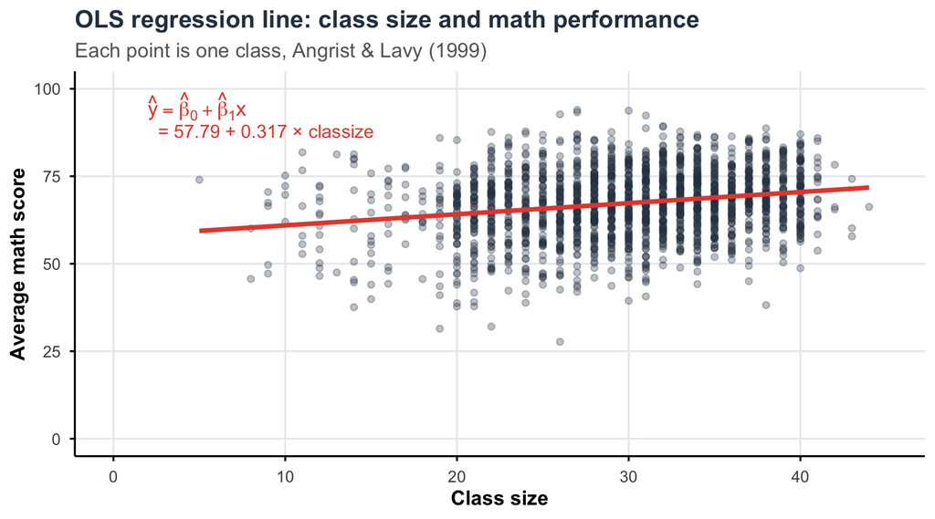

## Today’s lecture

**The big question:** How can we quantify and test the relationship between two numeric variables?

1. Motivation & data

2. The Simple Linear Regression model

3. Ordinary Least Squares estimation

**4. Goodness of fit ($R^2$)**

5. Inference: standard errors & the $t$-test

6. Reading regression output

# Goodness of Fit ($R^2$)

## How well does the model fit?

**Key question:** How much of the variation in $y$ does our model (the $x$ variable) explain?

Recall: $y_i = \hat{y}_i + e_i$

This gives us a **variance decomposition**:

$$\underbrace{Var(y)}_{\text{Total variation}} = \underbrace{Var(\hat{y})}_{\text{Explained}} + \underbrace{Var(e)}_{\text{Unexplained}}$$

In terms of sums of squares:

$$\underbrace{\sum_{i=1}^n (y_i - \bar{y})^2}_{\text{Sum of Squares Total =}SST} = \underbrace{\sum_{i=1}^n (\hat{y}_i - \bar{y})^2}_{\text{Sum of Squares Explained} = SSE} + \underbrace{\sum_{i=1}^n e_i^2}_{\text{Sum of Squared Residuals = }SSR}$$

## $R^2$: the coefficient of determination

**Definition**

$$R^2 = \frac{SSE}{SST} = 1 - \frac{SSR}{SST} \in [0, 1]$$

$R^2$ is the **fraction of the total variation in $y$ explained by the regression model**.

```r
summary(reg)$r.squared
```

```
[1] 0.04715649
```

**Interpretation:** Our class size variable explains 4.7% of the variation in average math scores across classes.

**Two important warnings**

1. Low $R^2$ does **not** mean the regression is useless; in social sciences, $R^2 < 0.1$ is common. Causal identification matters more than fit.
2. High $R^2$ does **not** mean the relationship is causal.

## $R^2$ and correlation (in simple regression)

In simple linear regression, $R^2$ equals the **squared correlation** between $x$ and $y$:

$$R^2 = r_{xy}^2$$

```r
cor(grades$classize, grades$avgmath)^2
```

```
[1] 0.04715649
```

```r
summary(reg)$r.squared
```

```
[1] 0.04715649
```

This confirms: the model explains only about 4.7% of the variation. Class size alone is not a great predictor of math scores.

## Today’s lecture

**The big question:** How can we quantify and test the relationship between two numeric variables?

1. Motivation & data

2. The Simple Linear Regression model

3. Ordinary Least Squares estimation

4. Goodness of fit ($R^2$)

**5. Inference: standard errors & the $t$-test**

6. Reading regression output

# Inference: Standard Errors & the $t$-test

## Why do we need inference?

Our OLS estimate $\hat{\beta}_1 = 0.317$ was computed from **one sample** of Israeli classrooms in 1991.

If we had drawn a **different sample** (different schools, different year), we would get a different estimate.

**The fundamental question:** Is the estimated relationship real? Could we have observed $\hat{\beta}_1 = 0.317$ simply by chance, even if there were truly **no** relationship between class size and math scores in the population?

To answer this, we need to know the **sampling distribution** of $\hat{\beta}_1$: how much it varies across samples.

This is exactly the framework from Lectures 4–5! The tool is the **standard error**.

## The population model

We distinguish between:

|  | Sample | Population |
| --- | --- | --- |
| Model | $y_i = \hat{\beta}_0 + \hat{\beta}_1 x_i + e_i$ | $y_i = \beta_0 + \beta_1 x_i + \varepsilon_i$ |
| Parameters | $\hat{\beta}_0, \hat{\beta}_1$ (estimated) | $\beta_0, \beta_1$ (unknown, true) |
| Errors | $e_i$ (residuals) | $\varepsilon_i$ (true error term) |

**Goal:** Use $\hat{\beta}_1$ to make inference about the true population parameter $\beta_1$.

For $\hat{\beta}_1$ to be a useful estimator of $\beta_1$, we want two things:

| Property | Meaning |
| --- | --- |
| **Unbiasedness** | $\hat{\beta}_1$ is correct *on average*: $E[\hat{\beta}_1] = \beta_1$ |
| **Precision** | $\hat{\beta}_1$ does not vary too much across samples: small $Var(\hat{\beta}_1)$ |

The **standard error** addresses precision. But what about bias?

## The variance of $\hat{\beta}_1$

One can show that:

$$Var(\hat{\beta}_1) = \frac{\sigma^2}{SST_x} = \frac{\sigma^2}{\sum_i(x_i-\bar{x})^2}$$

where $\sigma^2 = Var(\varepsilon_i)$ is the variance of the population error and $SST_x = \sum_i(x_i - \bar{x})^2$ is the total variation in $x$.

**Intuition:** $Var(\hat{\beta}_1)$ is smaller when the errors are less noisy (small $\sigma^2$) and when $x$ varies a lot across observations (large $SST_x$): both make the slope easier to pin down.

**Note**

This formula assumes observations are **independent** and that error variance is **constant** across values of $x$. Violations of either are covered in econometrics. See [the formal derivation here](https://statproofbook.github.io/P/slr-olsvar.html) if you are curious.

## Estimating $\sigma^2$: the residual standard error

The true $\sigma^2 = Var(\varepsilon_i)$ is unknown, so we estimate it from the residuals $e_i$.

**Why not just use $\frac{1}{n}\sum e_i^2$?** Because $e_i = y_i - \hat{\beta}_0 + \hat{\beta}_1 x_i$ and we “lose” **2 degrees of freedom** by estimate $\hat{\beta}_0$ and $\hat{\beta}_1$.

$$\hat{\sigma}^2 = \frac{SSR}{n - 2} = \frac{\sum_{i=1}^n e_i^2}{n-2}$$

$$\hat{\sigma} = \sqrt{\frac{SSR}{n-2}} \quad \text{(residual standard error)}$$

Dividing by $n-2$ instead of $n$ makes $\hat{\sigma}^2$ an **unbiased** estimator of $\sigma^2$.

## The standard error formula

Plugging $\hat{\sigma}^2$ into the variance formula:

$$\widehat{Var}(\hat{\beta}_1) = \frac{\hat{\sigma}^2}{SST_x} = \frac{SSR / (n-2)}{\sum_{i=1}^n (x_i - \bar{x})^2}$$

**Standard error of $\hat{\beta}_1$**

$$SE(\hat{\beta}_1) = \sqrt{\widehat{Var}(\hat{\beta}_1)} = \frac{\hat{\sigma}}{\sqrt{SST_x}} = \sqrt{\frac{SSR / (n-2)}{\sum_{i=1}^n (x_i-\bar{x})^2}}$$

We write $SE(\hat{\beta}_1)$ rather than $SD(\hat{\beta}_1)$ to remind ourselves this is an **estimate** of the standard deviation of $\hat{\beta}_1$’s sampling distribution.

## Three drivers of $SE(\hat{\beta}_1)$

$$SE(\hat{\beta}_1) = \frac{\hat{\sigma}}{\sqrt{SST_x}} = \frac{\sqrt{SSR/(n-2)}}{\sqrt{\sum_i (x_i - \bar{x})^2}}$$

| Driver | Intuition | Direction |
| --- | --- | --- |
| **More noise** ($\uparrow \hat{\sigma}$) | Harder to isolate signal from noise | $SE$ ↑ |
| **More spread in $x$** ($\uparrow SST_x$) | More variation in $x$ to pin down the slope | $SE$ ↓ |
| **More data** ($\uparrow n$) | $\hat{\sigma}$ stays stable (SSR grows, but divided by $n-2$); $\sqrt{SST_x}$ grows like $\sqrt{n}$ | $SE$ ↓ |

## Computing $SE(\hat{\beta}_1)$ in R

Let’s verify the formula step by step:

```r
reg    <- lm(avgmath ~ classize, data = grades)
n      <- nrow(grades)
SSR    <- sum(residuals(reg)^2)
SST_x  <- sum((grades$classize - mean(grades$classize))^2)

sigma_hat <- sqrt(SSR / (n - 2))       # residual standard error
SE_beta1  <- sigma_hat / sqrt(SST_x)   # SE of slope
```

```
sigma_hat: 9.3702
```

```
SE(beta1) by hand: 0.0318
```

```
SE(beta1) from lm():  0.0318
```

They match! The formula and `lm()` give the same answer.

## Your turn! #3

Using `reg_reading <- lm(avgverb ~ classize, grades)`:

1. Extract the vector of residuals with `residuals(reg_reading)`. Compute the **SSR** $= \sum_i e_i^2$.
2. Compute $\hat{\sigma} = \sqrt{SSR / (n-2)}$ where $n$ = `nrow(grades)`.
3. Compute $SST_x = \sum_i (x_i - \bar{x})^2$ using `classize`.
4. Compute $SE(\hat{\beta}_1)$ using the formula. Then compare with `summary(reg_reading)$coefficients[2, 2]`.
5. **Thinking question:** Suppose you repeated the regression but restricted to only classes of size 20–25 (much less variation in $x$). Would you expect $SE(\hat{\beta}_1)$ to be larger or smaller? Why?

# Hypothesis Testing & the $t$-statistic

## The default hypothesis test

By default, statistical software tests:

$$H_0: \beta_1 = 0 \qquad \text{vs} \qquad H_A: \beta_1 \neq 0$$

**Interpretation:** Under $H_0$, class size has **no linear relationship** with math scores in the population.

We ask: *how likely is it to observe our estimate $\hat{\beta}_1 = 0.317$ if the true $\beta_1$ were zero?*

To answer this, we need the **sampling distribution** of $\hat{\beta}_1$ under $H_0$.

## The $t$-statistic

The general formula standardises the distance between our estimate and the hypothesised value: $t = \frac{\hat{\beta}_1 - \beta_1^0}{SE(\hat{\beta}_1)},$ where $\beta_1^0$ is the null hypothesis value.

For $H_0: \beta_1 = 0$, this simplifies to: $t = \frac{\hat{\beta}_1}{SE(\hat{\beta}_1)}$

**Interpretation:** The $t$-statistic counts *how many standard errors* our estimate lies from zero.

Under $H_0$, this follows a $t$-distribution with $n-2$ degrees of freedom:

$$\boxed{t = \frac{\hat{\beta}_1}{SE(\hat{\beta}_1)} \sim t_{n-2} \quad \text{under } H_0}$$

## Why $t_{n-2}$ and not the standard normal?

Recall from Lecture 5: when we **estimate** $\sigma$ from the data (using $\hat{\sigma}$), there is extra uncertainty.

- If $\sigma$ were **known**, we’d use $\frac{\hat{\beta}_1 - \beta_1^0}{\sigma/\sqrt{SST_x}} \sim N(0,1)$
- Since $\sigma$ is **unknown** and estimated by $\hat{\sigma}$, we use a $t_{n-2}$ distribution

**Good news for large samples**

When $n$ is large (say $n > 100$), $t_{n-2} \approx N(0,1)$. In our data with $n \approx 2{,}000$, the difference is negligible.

The **degrees of freedom** $n - 2$ reflect that we estimated $\hat{\beta}_0$ and $\hat{\beta}_1$ from the data (2 parameters, 2 df lost).

## Computing the $t$-statistic

```r
reg <- lm(avgmath ~ classize, grades)
beta1_hat <- coef(reg)[2]
SE_beta1 <- summary(reg)$coefficients[2, 2]
t_stat <- beta1_hat / SE_beta1
```

```
beta1_hat: 0.3175
```

```
SE(beta1): 0.0318
```

```
t-stat:    9.991
```

$t = 0.3175 / 0.0318 = 9.99$

Our estimate is **10 standard errors** away from zero.

## The $p$-value

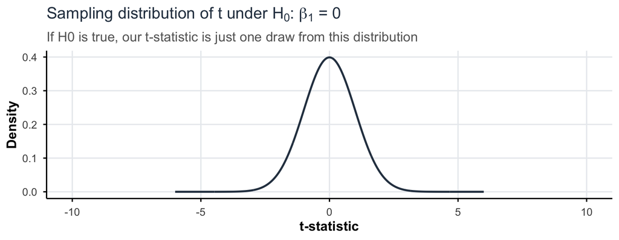

## The $p$-value

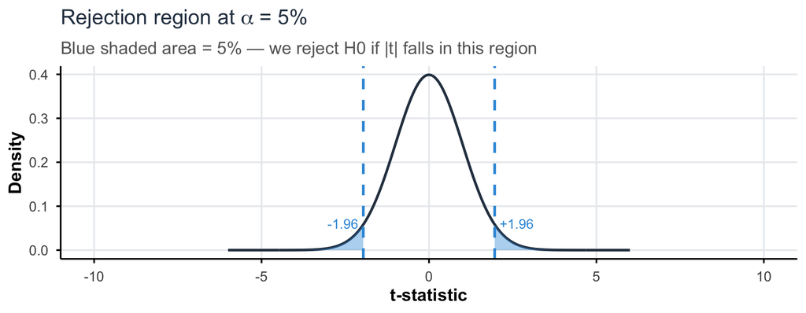

## The $p$-value

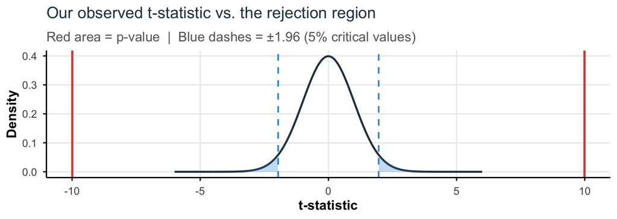

$$p\text{-value} = P\left(|t_{n-2}| \geq |t_\text{obs}|\right)$$

```r
p_value <- 2 * pt(-abs(t_stat), df = df)
```

```
p-value: 5.65e-23
```

## Decision rule and conclusion

At significance level $\alpha = 0.05$:

| **p-value** | 5.6e-23 |
| --- | --- |
| **Reject $H_0$?** | Yes — $p < 0.05$ |
| **Conclusion** | There is strong statistical evidence that class size is **significantly associated** with average math scores |

**Rule of thumb:** If $|t| > 2$ (more precisely, $|t| > t^*_{0.025, n-2} \approx 1.96$ for large $n$), we reject $H_0$ at the 5% level.

Here $|t| = 10$: well above 2.

**Warning**

Statistical significance ≠ practical significance. A coefficient can be statistically significant but economically tiny (especially with large $n$). Always report the magnitude and the SE alongside the p-value!

## Confidence interval for $\beta_1$

A 95% CI for $\beta_1$:

$$CI_{95\%} = \left[\hat{\beta}_1 \pm t^*_{0.025,\, n-2} \cdot SE(\hat{\beta}_1)\right]$$

For large $n$, $t^*_{0.025,\, n-2} \approx 1.96$.

```r
t_crit <- qt(0.975, df = n - 2)

CI_low  <- beta1_hat - t_crit * SE_beta1
CI_high <- beta1_hat + t_crit * SE_beta1
```

```
95% CI: [ 0.255 , 0.38 ]
```

**Interpretation:** We are 95% confident that the true $\beta_1$ lies between 0.255 and 0.38.

Notice: the CI does **not** include 0, which is consistent with rejecting $H_0: \beta_1 = 0$ at the 5% level.

## Your turn! #4

Now apply everything we covered to the **verbal (reading) score** regression.

1. Run `reg_verb <- lm(avgverb ~ classize, data = grades)` and print `summary(reg_verb)`.
2. From the output, identify the estimate, SE, $t$-statistic, and p-value for `classize`. What do they tell you?
3. Verify the $t$-statistic manually: compute `coef(reg_verb)[2] / summary(reg_verb)$coefficients[2, 2]`.
4. Compute a **95% confidence interval** for $\beta_1$ by hand using `qt(0.975, df = nrow(grades) - 2)`.
5. Is the effect of class size on verbal scores statistically significant at the 5% level? How does it compare in magnitude to the math regression?
6. *(Bonus)* A classmate argues: “Since both coefficients are positive, larger classes **cause** better outcomes.” What is wrong with this interpretation? Name at least one potential confounder.

## Today’s lecture

**The big question:** How can we quantify and test the relationship between two numeric variables?

1. Motivation & data

2. The Simple Linear Regression model

3. Ordinary Least Squares estimation

4. Goodness of fit ($R^2$)

5. Inference: standard errors & the $t$-test

**6. Reading regression output**

# Reading Regression Output

## `summary()` output

```r
summary(reg)
```

```
Call:
lm(formula = avgmath ~ classize, data = grades)

Residuals:
    Min      1Q  Median      3Q     Max
-38.359  -6.039   0.356   6.593  27.564

Coefficients:
            Estimate Std. Error t value Pr(>|t|)
(Intercept) 57.79392    0.97365  59.358   <2e-16 ***
classize     0.31749    0.03178   9.991   <2e-16 ***
---
Signif. codes:  0 '***' 0.001 '**' 0.01 '*' 0.05 '.' 0.1 ' ' 1

Residual standard error: 9.37 on 2017 degrees of freedom
Multiple R-squared:  0.04716,   Adjusted R-squared:  0.04668
F-statistic: 99.82 on 1 and 2017 DF,  p-value: < 2.2e-16
```

## Anatomy of the regression table

|  | Estimate | Std. Error | t value | Pr(>\|t\|) |
| --- | --- | --- | --- | --- |
| (Intercept) | 57.7939 | 0.9736 | 59.3581 | 0 |
| classize | 0.3175 | 0.0318 | 9.9911 | 0 |

| Column | Meaning |
| --- | --- |
| `Estimate` | OLS coefficient $\hat{\beta}_k$ |
| `Std. Error` | $SE(\hat{\beta}_k)$: estimated SD of the sampling distribution of $\hat{\beta}_k$ |
| `t value` | $t = \hat{\beta}_k / SE(\hat{\beta}_k)$: test statistic for $H_0: \beta_k = 0$ |
| `Pr(>\|t\|)` | Two-sided p-value for $H_0: \beta_k = 0$ |

Significance codes: `***` ($p < 0.001$), `**` ($p < 0.01$), `*` ($p < 0.05$), `.` ($p < 0.1$)

## `tidy()` from `broom`: cleaner output

```r
library(broom)
tidy(reg, conf.int = TRUE, conf.level = 0.95)
```

```
# A tibble: 2 × 7
  term        estimate std.error statistic  p.value conf.low conf.high
  <chr>          <dbl>     <dbl>     <dbl>    <dbl>    <dbl>     <dbl>
1 (Intercept)   57.8      0.974      59.4  0          55.9      59.7
2 classize       0.317    0.0318      9.99 5.65e-23    0.255     0.380
```

`tidy()` returns a data frame: much easier to work with programmatically.

The `conf.low` and `conf.high` columns give the 95% CI directly.

## Putting it all together: Angrist & Lavy

```r
reg_math  <- lm(avgmath ~ classize, grades)
reg_verb  <- lm(avgverb ~ classize, grades)

tidy(reg_math, conf.int = TRUE) %>% filter(term == "classize")
```

```
# A tibble: 1 × 7
  term     estimate std.error statistic  p.value conf.low conf.high
  <chr>       <dbl>     <dbl>     <dbl>    <dbl>    <dbl>     <dbl>
1 classize    0.317    0.0318      9.99 5.65e-23    0.255     0.380
```

```r
tidy(reg_verb, conf.int = TRUE) %>% filter(term == "classize")
```

```
# A tibble: 1 × 7
  term     estimate std.error statistic  p.value conf.low conf.high
  <chr>       <dbl>     <dbl>     <dbl>    <dbl>    <dbl>     <dbl>
1 classize    0.222    0.0256      8.69 7.51e-18    0.172     0.272
```

**Math:** $\hat{\beta}_1 = 0.317$ (SE = 0.032, $p < 0.001$)

**Verbal:** $\hat{\beta}_1 = 0.222$ (SE = 0.026)

Both positive and statistically significant; but this doesn’t mean larger classes *cause* better outcomes (confounders!).

# Wrapping up

## What we covered today

**Simple Linear Regression: the full workflow**

1. **Model:** $y_i = \hat{\beta}_0 + \hat{\beta}_1 x_i + e_i$: summarises a linear relationship with a line
2. **OLS:** Minimises $\sum e_i^2$ → unique formulas for $\hat{\beta}_0$ and $\hat{\beta}_1$
3. **Goodness of fit:** $R^2 = 1 - SSR/SST$: fraction of variation explained
4. **Standard error:** $SE(\hat{\beta}_1) = \hat{\sigma} / \sqrt{SST_x}$: quantifies sampling uncertainty
5. **$t$-test:** $t = \hat{\beta}_1 / SE(\hat{\beta}_1) \sim t_{n-2}$ under $H_0: \beta_1 = 0$
6. **Confidence interval:** $\hat{\beta}_1 \pm t^*_{0.025} \cdot SE(\hat{\beta}_1)$

## Looking ahead

**Today’s limitation:** we only included class size. But other variables (% disadvantaged students, school type, etc.) are correlated with both class size *and* performance.

→ **Next year:** **Multiple regression**: control for multiple variables simultaneously, isolate the effect of class size, and understand **omitted variable bias** formally.

**The bigger picture**

Regression is a tool for *description* and *prediction*. To make **causal claims**, we need careful research designs: randomised experiments, natural experiments, instrumental variables, regression discontinuity… This is the realm of econometrics and causal inference!

# Thanks for a great semester!